# Steps13_15_lakefs

```python
# I used ChatGTP 3.5 and 4 for assistance
```

```python
!pip install tensorflow_privacy
```

```python
from tensorflow_privacy.privacy.optimizers.dp_optimizer_keras import DPKerasSGDOptimizer
```

[output not shown]

```python
# Downgrade to compatible versions
!pip install -U "tensorflow==2.13.0" "tensorflow-estimator==2.13.0" "scipy==1.7.3" --quiet
!pip install "tensorflow-privacy==0.8.7" --quiet

# Restart the runtime after this step
```

[output not shown]

```python
!pip uninstall -y tensorflow-privacy
```

```
Found existing installation: tensorflow_privacy 0.9.0
Uninstalling tensorflow_privacy-0.9.0:
  Successfully uninstalled tensorflow_privacy-0.9.0
```

```python
!pip install git+https://github.com/tensorflow/privacy.git@main
```

[output not shown]

```python
!pip install git+https://github.com/tensorflow/privacy.git@master
```

```
  Cloning https://github.com/tensorflow/privacy.git (to revision master) to /tmp/pip-req-build-bjly6npr
  Running command git clone --filter=blob:none --quiet https://github.com/tensorflow/privacy.git /tmp/pip-req-build-bjly6npr
  Resolved https://github.com/tensorflow/privacy.git to commit f27d79d505e3734ec38df688666d48f025132b92
  Preparing metadata (setup.py) ... done
```

```python
from tensorflow_privacy.privacy.optimizers.dp_optimizer_keras import DPKerasSGDOptimizer
```

[output not shown]

```python
import tensorflow as tf
print(tf.__version__)
```

```
2.15.0
```

```python
!pip install tensorflow-privacy==0.8.12
```

[output not shown]

```python
!pip install tensorflow-privacy==0.8.12 --no-deps
```

```
  Using cached tensorflow_privacy-0.8.12-py3-none-any.whl.metadata (962 bytes)
Downloading tensorflow_privacy-0.8.12-py3-none-any.whl (405 kB)
   ━━━━━━━━━━━━━━━━━━━━━━━━━━━━━━━━━━━━━━━━ 405.5/405.5 kB 7.8 MB/s eta 0:00:00
  Attempting uninstall: tensorflow-privacy
    Found existing installation: tensorflow_privacy 0.9.0
    Uninstalling tensorflow_privacy-0.9.0:
      Successfully uninstalled tensorflow_privacy-0.9.0
```

```python
from tensorflow_privacy.privacy.optimizers.dp_optimizer_keras import DPKerasSGDOptimizer
```

```python
from tensorflow.keras import layers
```

### Use tensor flow privacy library with the dataset v2 and calculate the metrics for the new DP model.

```python
from google.colab import files
uploaded = files.upload()
```

```
Saving X_test_v2.npy to X_test_v2.npy
Saving X_train_v2.npy to X_train_v2.npy
Saving y_test_v2.npy to y_test_v2.npy
Saving y_train_v2.npy to y_train_v2.npy
```

```python
import numpy as np

X_train_v2 = np.load("X_train_v2.npy")
y_train_v2 = np.load("y_train_v2.npy")
X_test_v2 = np.load("X_test_v2.npy")
y_test_v2 = np.load("y_test_v2.npy")
```

```python
import tensorflow as tf
from tensorflow.keras import layers
from tensorflow.keras.regularizers import l2
from tensorflow.keras.callbacks import EarlyStopping, ModelCheckpoint
from tensorflow_privacy.privacy.optimizers.dp_optimizer_keras import DPKerasSGDOptimizer
```

Next I will train a **differentially private neural network** for a **regression task** using TensorFlow and TensorFlow Privacy.

### **Model Architecture**

- A 3-layer neural network using `tf.keras.Sequential`.
- Uses ReLU activations and dropout for regularization.
- Output layer has 1 neuron for regression output (no activation).

### **Differential Privacy**

- Uses **DP-SGD** optimizer (`DPKerasSGDOptimizer`) for training with:
  - Gradient clipping (`l2_norm_clip = 1.0`)
  - Gaussian noise added to gradients (`noise_multiplier = 1.1`)
  - Single microbatch (`num_microbatches = 1`)

### **Training Setup**

- Compiles the model with **MAE loss and metric**.
- Uses callbacks for:
  - **Early stopping** to prevent overfitting.
  - **Model checkpoint** to save the best model.

### **Execution**

- Trains the model on `X_train_v2`/`y_train_v2` for 10 epochs.
- Evaluates it on `X_test_v2`/`y_test_v2`.
- Makes predictions on the test set.

```python
# Build the model using tf.keras.Sequential
model_v3 = tf.keras.Sequential([
    layers.Dense(64, input_dim=X_train_v2.shape[1], activation='relu', kernel_regularizer=l2(0.01)),
    layers.Dropout(0.5),
    layers.Dense(32, activation='relu', kernel_regularizer=l2(0.01)),
    layers.Dropout(0.5),
    layers.Dense(1)  # Output layer for regression
])

# Define hyperparameters for differential privacy
l2_norm_clip = 1.0  # Clipping norm
noise_multiplier = 1.1  # Noise multiplier
num_microbatches = 1  # Number of microbatches

# Create a DP-SGD optimizer
optimizer = DPKerasSGDOptimizer(
    l2_norm_clip=l2_norm_clip,
    noise_multiplier=noise_multiplier,
    num_microbatches=num_microbatches
)

# Compile the model with the DP-SGD optimizer
model_v3.compile(optimizer=optimizer,
                 loss='mean_absolute_error',  # Use MAE for regression
                 metrics=['mean_absolute_error'])  # MAE as the metric

# Define callbacks for early stopping and model_v3 checkpoint
early_stop = EarlyStopping(monitor='val_loss', patience=5, restore_best_weights=True)
model_v3_checkpoint = ModelCheckpoint('model_v3_dp.h5', monitor='val_loss', save_best_only=True)

# Train the model_v3
history_v3  = model_v3.fit(X_train_v2, y_train_v2, epochs=10, batch_size=64, validation_split=0.2, callbacks=[early_stop, model_v3_checkpoint])

# Evaluate the model_v3
loss_v3 = model_v3.evaluate(X_test_v2, y_test_v2)
print(f'Test loss: {loss_v3}')

# Make predictions_v3
y_pred_v3 = model_v3.predict(X_test_v2)
```

```
Test loss: [486.8015441894531, 404.8604431152344]
```

```python
import matplotlib.pyplot as plt
import pandas as pd
import seaborn as sns
```

```
Test loss_v3: 404.8604431152344
MSE: 415619.3606957802
MAE: 404.86049746101475
MAPE: 0.443542770632004
R-squared: -4.411078903259095
Adjusted R-squared: -4.700619090187871
MBD: -185.54694194711132
```

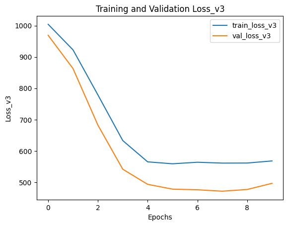

```
Summary statistics for predictions:
        predictions
count   6006.000000
mean     829.948242
std      634.956970
min      194.644272
25%      533.819626
50%      702.063110
75%      917.398453
max    14854.196289
```

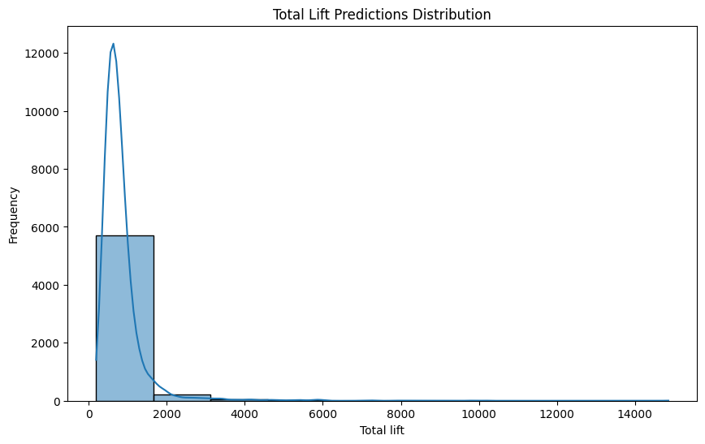

```python
# Evaluate the model
loss_v3 = model_v3.evaluate(X_test_v2, y_test_v2)[1]
print(f'Test loss_v3: {loss_v3}')

from sklearn.metrics import mean_squared_error, mean_absolute_percentage_error, r2_score

# Ensure predictions_v3 and y_test_v2 are 1-dimensional arrays
y_pred_v3 = y_pred_v3.flatten()
y_test_v2 = y_test_v2

# Calculate the metrics
mse_3 = mean_squared_error(y_test_v2, y_pred_v3)
mae_3 = np.mean(np.abs(y_pred_v3 - y_test_v2))
mape_3 = mean_absolute_percentage_error(y_test_v2, y_pred_v3)
r2_3 = r2_score(y_test_v2, y_pred_v3)
adjusted_r2_3 = 1 - (1-r2_3)*(len(y_test_v2)-1)/(len(y_test_v2)-X_test_v2.shape[1]-1)
mbd_3 = np.mean(y_pred_v3 - y_test_v2)

# Print the metrics
print(f'MSE: {mse_3}')
print(f'MAE: {mae_3}')
print(f'MAPE: {mape_3}')
print(f'R-squared: {r2_3}')
print(f'Adjusted R-squared: {adjusted_r2_3}')
print(f'MBD: {mbd_3}')

# Plot the training and validation loss_v2
plt.plot(history_v3.history['loss'], label='train_loss_v3')
plt.plot(history_v3.history['val_loss'], label='val_loss_v3')
plt.xlabel('Epochs')
plt.ylabel('Loss_v3')
plt.title('Training and Validation Loss_v3')
plt.legend()
plt.show()

# 3. Summary Statistics
print("\nSummary statistics for predictions:")
# Convert to a Pandas DataFrame
predictions_v3_df = pd.DataFrame(y_pred_v3, columns=['predictions'])
# Now you can use describe()
print(predictions_v3_df.describe())

plt.figure(figsize=(10, 6))
sns.histplot(y_pred_v3, bins=10, kde=True)
plt.title('Total Lift Predictions Distribution')
plt.xlabel('Total lift')
plt.ylabel('Frequency')
plt.show()
```

### Compute the DP epsilon using TensorFlow privacy compute_dp_sgd_privacy.

```python
from tensorflow_privacy.privacy.analysis import compute_dp_sgd_privacy_lib

# Parameters for DP-SGD
batch_size = 32
num_epochs = 50
num_train_samples = X_train_v2.shape[0]
noise_multiplier = 1.1
l2_norm_clip = 1.0

# Compute DP-SGD privacy parameters
epsilon, _ = compute_dp_sgd_privacy_lib.compute_dp_sgd_privacy(
    n=num_train_samples,
    batch_size=batch_size,
    noise_multiplier=noise_multiplier,
    epochs=num_epochs,
    delta=1e-5
)

print(f"DP-SGD with (epsilon, delta) = ({epsilon}, 1e-5)")
```

[output not shown]

```
DP-SGD with (epsilon, delta) = (1.2263414486109068, 1e-5)
```

### Compare and comment on the accuracy/metrics of the non-DP and DP models using dataset v2.

```python
# From previous notebook for non-DP
loss_v2 = 71.05628967285156
mse_2 = 13307.079262892292
mae_2 = 61.17655838309945
mape_2 = 0.07651405018869077
r2_2 = 0.8267509585143247
adjusted_r2_2 = 0.8174806150664069
mbd_2 = -46.120207563305634
```

```python
# Print the metrics
print(f'Test loss: {round(loss_v2,2),round(loss_v3,2)}')
print(f'MSE: {round(mse_2,2),round(mse_3,2)}')
print(f'MAE: {round(mae_2,2),round(mae_3,2)}')
print(f'MAPE: {round(mape_2,2),round(mape_3,2)}')
print(f'R-squared: {round(r2_2,2),round(r2_3,2)}')
print(f'Adjusted R-squared: {round(adjusted_r2_2,2),round(adjusted_r2_3,2)}')
print(f'MBD: {round(mbd_2,2),round(mbd_3,2)}')
```

```
Test loss: (71.06, 404.86)
MSE: (13307.08, 415619.36)
MAE: (61.18, 404.86)
MAPE: (0.08, 0.44)
R-squared: (0.83, -4.41)
Adjusted R-squared: (0.82, -4.7)
MBD: (-46.12, -185.55)
```

### 📊 **Conclusion: Comparing Non-DP vs DP Model Performance**

A **clear trade-off between accuracy and privacy**:

| Metric | Non-DP Model (`_v2`) | DP Model (`_v3`) |
| --- | --- | --- |
| **Test Loss (MAE)** | 71.06 | 404.86 |
| **MSE** | 13,307.08 | 415,619.36 |
| **MAE** | 61.18 | 404.86 |
| **MAPE** | 8% | 44% |
| **R-squared** | 0.83 | -4.41 |
| **Adjusted R-squared** | 0.82 | -4.70 |
| **MBD** | -46.12 | -185.55 |

- **Non-DP Model** performed **very well**, with high R² (0.83) and low errors.
- **DP Model** (with differential privacy) performed **much worse**:
  - R² dropped **dramatically to -4.41**, meaning the model fit is worse than just predicting the mean.
  - **MAE and MSE increased significantly**, showing a large drop in predictive accuracy.

### 🧾 Interpretation

[output not shown]

- Can try tuning:
  - **Lower `noise_multiplier`** (e.g., 0.8 instead of 1.1)
  - **More epochs** or **larger model**
  - Use **Adam** optimizer with DP instead of SGD (via `DPKerasAdamOptimizer`)
- Or use **privacy-preserving training** only when required by compliance